# UN_PeopleAnalytics

Reference: https://peopleanalytics-regression-book.org/ord-reg.html

In medical settings, the difference between moving from a healthy to an early-stage disease may not be equivalent to moving from an early-stage disease to an intermediate- or advanced-stage. Equally, it may be a much bigger psychological step for an individual to say that they are very dissatisfied in their work than it is to say that they are very satisfied in their work.

Therefore, in the proportional odds model, we ‘divide’ the probability space at each level of the outcome variable and consider each as a binomial logistic regression model. For example, at rating 3, we generate a binomial logistic regression model of P(y>τ3).

Proportional odds logistic regression can be used when there are more than two outcome categories that have an order. An important underlying assumption is that no input variable has a disproportionate effect on a specific level of the outcome variable. This is known as the proportional odds assumption. This assumption means that the ‘slope’ of the logistic function is the same for all category cutoffs

```r
library(readr)
```

```r
d <- read.csv("finaldf2.csv")
```

```r
head(d)
```

```
##   Index.No Organization Gender       Nationality  Hire.Date DS.Location
## 1   AAAAAZ       UNICEF   Male Equatorial Guinea 2015-04-15        Bata
## 2    AAADK       UNICEF Female     Cote d'Ivoire 2009-08-24         Man
## 3   AAAKFZ       UNICEF Female          Paraguay 2015-04-15    Asuncion
## 4   AAAKKD         UNDP   Male             Kenya 2008-03-13     Nairobi
## 5   AAAKXX       UNICEF   Male    United Kingdom 2010-09-06      Beirut
## 6   AAAOKA       UNICEF Female        Bangladesh 2015-04-15  Chittagong
##          DS.Country Family.Non.Family Position_Count Years.of.Service  Age
## 1 Equatorial Guinea                 F              2                5 34.5
## 2     Cote D'Ivoire                 N              4               11 44.5
## 3          Paraguay                 F              2                5 34.5
## 4             Kenya                 F              2               11 44.5
## 5           Lebanon                 F              1               10 44.5
## 6        Bangladesh                 F              1                5 44.5
##   Hardship_min Hardship_median Hardship_max Min_Incumbent Max_Incumbent
```

[output cut: 118 more lines]

```r
#View(d)
```

performance_level = {‘Performance below standards’:0,‘Low Achievement’:1, ‘Partially successful performance’:2, ‘Solid Achievement’:3, ‘Successful performance’:4, ‘Successful PLUS performance’:4, ‘Outstanding Achievement’:5}

```r
# change to ordered factor

d$Performance_mean <- ordered(d$Performance_mean, levels = c("0","1","2","3","4","5"))

d$Age <- ordered(d$Age, levels = c("24.5","34.5","44.5","54.5","64.5"))

d$Hardship_min <- ordered(d$Hardship_min , levels = c("0","1","2","3","4","5"))

d$Hardship_max <- ordered(d$Hardship_max, levels = c("0","1","2","3","4","5"))

d$Hardship_median <- as.integer(d$Hardship_median)
d$Hardship_median <- ordered(d$Hardship_median, levels = c("0","1","2","3","4","5"))

d$Min_Incumbent <- ordered(d$Min_Incumbent, levels = c("1","2","3","4","5","6","7","8","9","10","11","12","13","14","15","16","17","18"))

d$Max_Incumbent <- ordered(d$Max_Incumbent, levels = c("1","2","3","4","5","6","7","8","9","10","11","12","13","14","15","16","17","18"))

d$Difference_incumbent <- ordered(d$Difference_incumbent, levels = c("0","1","2","3","4","5","6","7","8","9","10","11","12","13"))
```

```r
# Change to factor
categories <- c("Organization", "Gender", "Nationality", "DS.Location", "DS.Country", "Family.Non.Family")

d[ ,categories] <- lapply(d[ ,categories], as.factor)
```

```r
library(dplyr)
d1 = select(d, -c("Index.No","Nationality","DS.Location","DS.Country","Hire.Date"))
length(colnames(d1))
```

```
## [1] 70
```

```r
group0 <- select(d1, c("Organization","Gender","Family.Non.Family","Hardship_min","Hardship_median","Hardship_max","Performance_mean"))
group000 <- select(d1, c("Min_Incumbent","Max_Incumbent","Difference_incumbent"))
```

```r
d2 = select(d1, -c("Organization","Gender","Family.Non.Family","Hardship_min","Hardship_median","Hardship_max","Min_Incumbent","Max_Incumbent","Performance_mean","Difference_incumbent"))
length(colnames(d2))
```

```
## [1] 60
```

```r
group1 = d2[c(1:10)]
group2 = d2[c(11:20)]
group3 = d2[c(21:30)]
group4 = d2[c(31:40)]
group5 = d2[c(41:50)]
group6 = d2[c(51:60)]
```

```r
library(tidyr)
library(ggplot2)
```

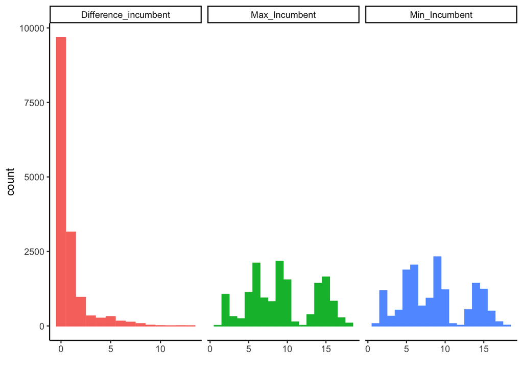

```r
group000 %>% gather() %>% group_by(key) %>% arrange(value) %>%
  ggplot(aes(as.numeric(value), fill = key, color = key)) + geom_bar() +
  facet_wrap(~key, scale='free_x') +
  theme_classic() +
  theme(legend.position="none") + xlab(" ")
```

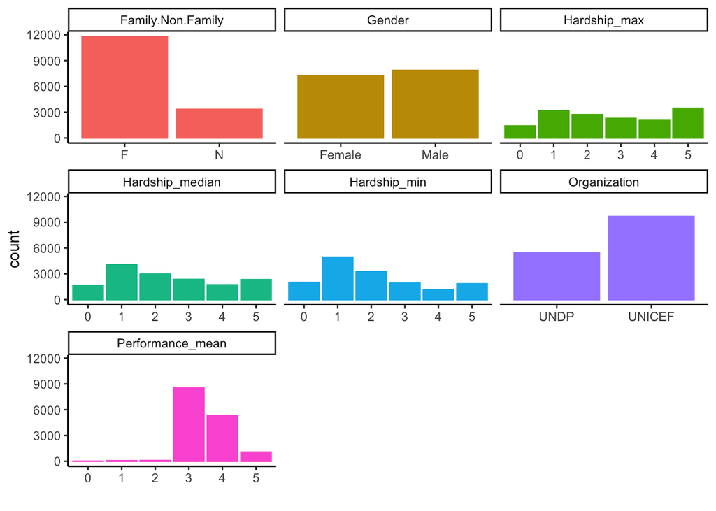

```r
ggplot(gather(group0) ,aes(value, fill = key, color = key)) + geom_bar() +
  facet_wrap(~key, scale='free_x') +
  theme_classic() +
  theme(legend.position="none")+ xlab(" ")
```

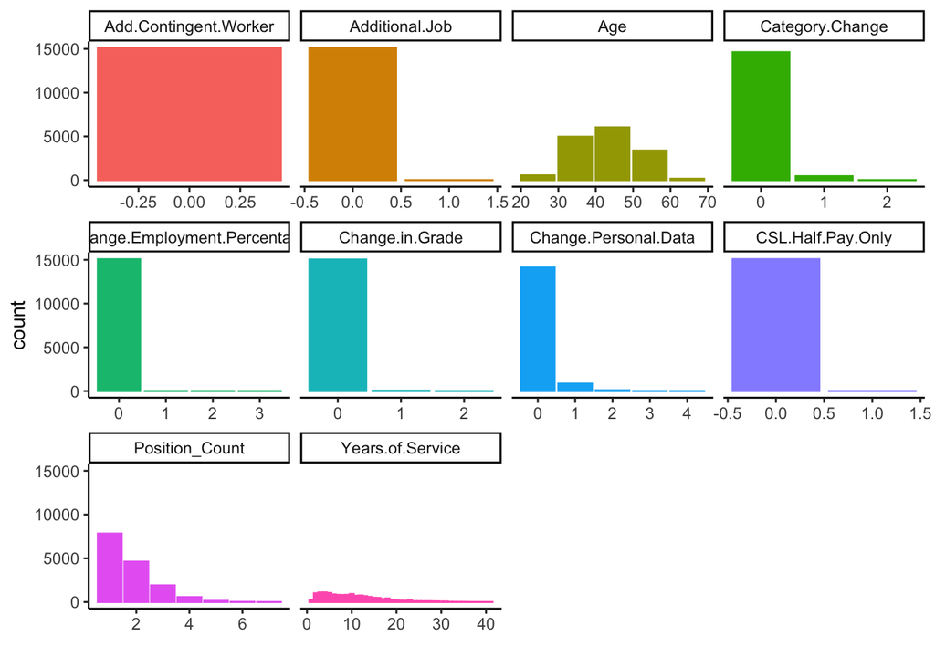

```r
group1 %>% gather() %>% group_by(key) %>% arrange(value) %>%
  ggplot(aes(as.numeric(value), fill = key, color = key)) + geom_bar() +
  facet_wrap(~key, scale='free_x') +
  theme_classic() +
  theme(legend.position="none")+ xlab(" ")
```

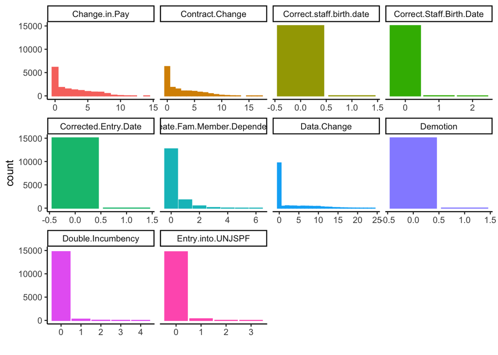

```r
group2 %>% gather() %>% group_by(key) %>% arrange(value) %>%
  ggplot(aes(as.numeric(value), fill = key, color = key)) + geom_bar() +
  facet_wrap(~key, scale='free_x') +
  theme_classic() +
  theme(legend.position="none")+ xlab(" ")
```

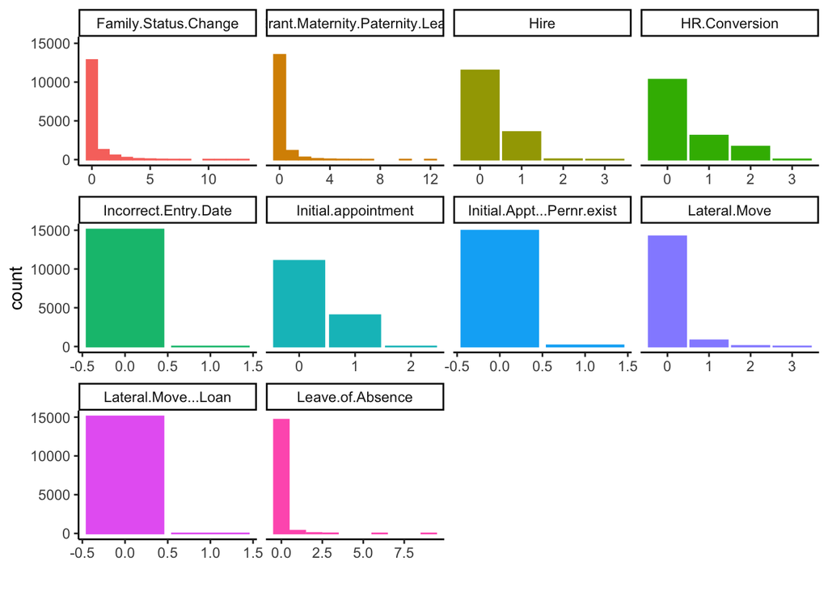

```r
group3 %>% gather() %>% group_by(key) %>% arrange(value) %>%
  ggplot(aes(as.numeric(value), fill = key, color = key)) + geom_bar() +
  facet_wrap(~key, scale='free_x') +
  theme_classic() +
  theme(legend.position="none")+ xlab(" ")
```

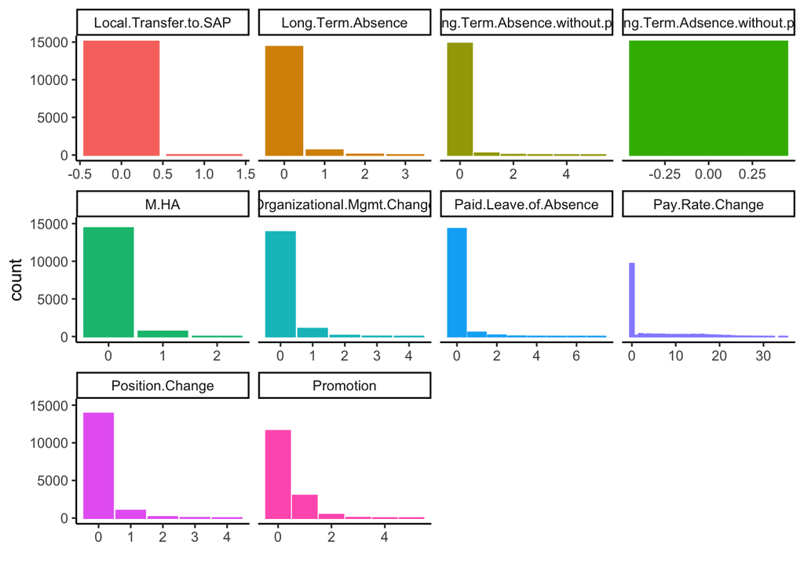

```r
group4 %>% gather() %>% group_by(key) %>% arrange(value) %>%
  ggplot(aes(as.numeric(value), fill = key, color = key)) + geom_bar() +
  facet_wrap(~key, scale='free_x') +
  theme_classic() +
  theme(legend.position="none")+ xlab(" ")
```

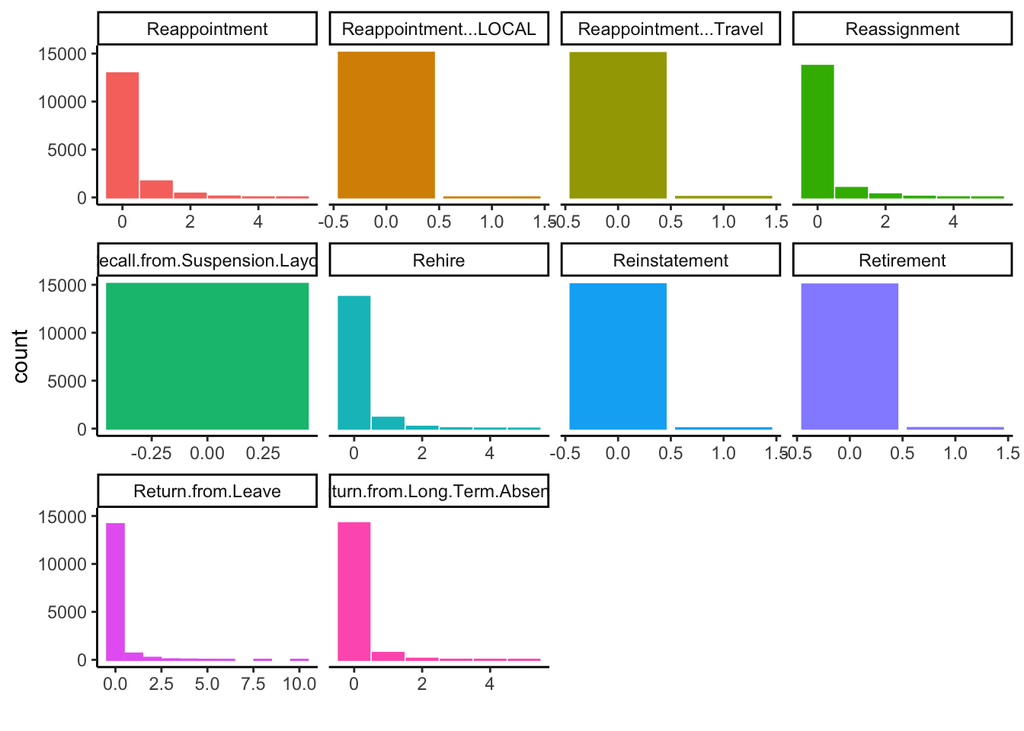

```r
group5 %>% gather() %>% group_by(key) %>% arrange(value) %>%
  ggplot(aes(as.numeric(value), fill = key, color = key)) + geom_bar() +
  facet_wrap(~key, scale='free_x') +
  theme_classic() +
  theme(legend.position="none")+ xlab(" ")
```

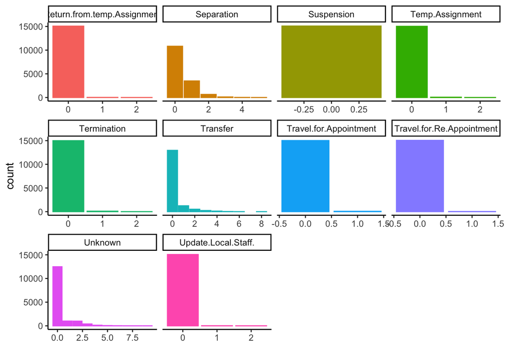

```r
group6 %>% gather() %>% group_by(key) %>% arrange(value) %>%
  ggplot(aes(as.numeric(value), fill = key, color = key)) + geom_bar() +
  facet_wrap(~key, scale='free_x') +
  theme_classic() +
  theme(legend.position="none")+ xlab(" ")
```

```r
str(d)
```

```
## 'data.frame':    15090 obs. of  75 variables:
##  $ Index.No                      : chr  "AAAAAZ" "AAADK" "AAAKFZ" "AAAKKD" ...
##  $ Organization                  : Factor w/ 2 levels "UNDP","UNICEF": 2 2 2 1 2 2 2 2 2 2 ...
##  $ Gender                        : Factor w/ 2 levels "Female","Male": 2 1 1 2 2 1 1 2 2 2 ...
##  $ Nationality                   : Factor w/ 210 levels "Afghanistan",..: 61 44 142 96 196 13 136 144 116 65 ...
##  $ Hire.Date                     : chr  "2015-04-15" "2009-08-24" "2015-04-15" "2008-03-13" ...
##  $ DS.Location                   : Factor w/ 405 levels "Abeche","Abidjan",..: 44 238 24 277 48 89 316 244 287 343 ...
##  $ DS.Country                    : Factor w/ 160 levels "Afghanistan",..: 48 36 109 73 80 10 105 111 90 50 ...
##  $ Family.Non.Family             : Factor w/ 2 levels "F","N": 1 2 1 1 1 1 2 1 1 2 ...
##  $ Position_Count                : int  2 4 2 2 1 1 1 1 2 1 ...
##  $ Years.of.Service              : int  5 11 5 11 10 5 5 13 8 5 ...
##  $ Age                           : Ord.factor w/ 5 levels "24.5"<"34.5"<..: 2 3 2 3 3 3 1 4 3 2 ...
##  $ Hardship_min                  : Ord.factor w/ 6 levels "0"<"1"<"2"<"3"<..: 5 3 2 3 3 4 6 2 5 5 ...
##  $ Hardship_median               : Ord.factor w/ 6 levels "0"<"1"<"2"<"3"<..: 5 4 2 3 3 4 6 2 5 5 ...
##  $ Hardship_max                  : Ord.factor w/ 6 levels "0"<"1"<"2"<"3"<..: 5 6 2 4 3 4 6 2 5 6 ...
```

[output cut: 61 more lines]

```r
library(MASS)
polr_model <- polr(formula = Performance_mean ~ Organization + Gender + Family.Non.Family + Position_Count + Years.of.Service + Age + Max_Incumbent + Hardship_max, data = d, Hess=TRUE)

summary(polr_model)
```

```
## Call:
## polr(formula = Performance_mean ~ Organization + Gender + Family.Non.Family +
##     Position_Count + Years.of.Service + Age + Max_Incumbent +
##     Hardship_max, data = d, Hess = TRUE)
##
## Coefficients:
##                         Value Std. Error    t value
## OrganizationUNICEF -2.8512427   0.044836 -63.592628
## GenderMale         -0.1295928   0.040408  -3.207100
## Family.Non.FamilyN  0.1128081   0.071569   1.576215
## Position_Count     -0.0008754   0.022810  -0.038379
## Years.of.Service    0.0080887   0.003249   2.489591
## Age.L              -0.5972806   0.139015  -4.296518
## Age.Q               0.0277177   0.113531   0.244142
## Age.C               0.0004899   0.073990   0.006621
## Age^4               0.0273968   0.041455   0.660883
## Max_Incumbent.L     1.0207967   0.257259   3.967979
## Max_Incumbent.Q     0.5920147   0.297938   1.987043
## Max_Incumbent.C    -0.2178560   0.298165  -0.730657
## Max_Incumbent^4     0.4858494   0.257322   1.888100
## Max_Incumbent^5    -0.2808237   0.259176  -1.083524
## Max_Incumbent^6     0.3486233   0.182601   1.909204
## Max_Incumbent^7    -0.3243639   0.190970  -1.698505
## Max_Incumbent^8     0.0704237   0.165797   0.424760
## Max_Incumbent^9    -0.1489638   0.124163  -1.199741
## Max_Incumbent^10    0.3386509   0.177641   1.906373
## Max_Incumbent^11   -0.2688180   0.123077  -2.184139
## Max_Incumbent^12   -0.0027472   0.155411  -0.017677
## Max_Incumbent^13    0.0419569   0.180182   0.232859
## Max_Incumbent^14    0.1208899   0.101806   1.187449
## Max_Incumbent^15   -0.0612135   0.184782  -0.331275
## Max_Incumbent^16   -0.1648753   0.240105  -0.686681
## Max_Incumbent^17    0.0375490   0.162809   0.230633
## Hardship_max.L     -0.3130690   0.065951  -4.746961
## Hardship_max.Q     -0.0061841   0.055219  -0.111991
## Hardship_max.C     -0.0051842   0.048961  -0.105884
## Hardship_max^4      0.0594280   0.047611   1.248206
## Hardship_max^5      0.0304152   0.046985   0.647332
##
## Intercepts:
##     Value    Std. Error t value
## 0|1 -10.0730   0.3460   -29.1122
## 1|2  -7.9743   0.1494   -53.3699
## 2|3  -7.2098   0.1226   -58.7940
## 3|4  -1.3134   0.0886   -14.8212
## 4|5   1.7641   0.0899    19.6296
##
## Residual Deviance: 21252.54
## AIC: 21324.54
## (4 observations deleted due to missingness)
```

```r
#install.packages("brant")
#library(brant)
# brant::brant(polr_model)
```